# Examples of map layers

# osm-seamap

`plotRGB(openmap(x,path="osm-seamap"))`

© [OpenStreetMap](http://openstreetmap.org/copyright) contributors. Data by [OpenStreetMap](http://openstreetmap.org), available under the [Open Database License](http://opendatacommons.org/licenses/odbl), cartography is licensed as [CC BY-SA](http://creativecommons.org/licenses/by-sa/2.0).

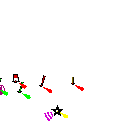

# osm-fr

`plot(openmap(x,path="osm-fr"))`

© [OpenStreetMap](http://openstreetmap.org/copyright) contributors. Data by [OpenStreetMap](http://openstreetmap.org), available under the [Open Database License](http://opendatacommons.org/licenses/odbl), cartography is licensed as [CC BY-SA](http://creativecommons.org/licenses/by-sa/2.0).

[figure not shown]

[figure not shown]

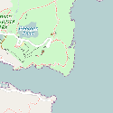

# hyda

`plot(openmap(x,path="hyda"))`

© [OpenStreetMap](http://openstreetmap.org/copyright) contributors. Data by [OpenStreetMap](http://openstreetmap.org), available under the [Open Database License](http://opendatacommons.org/licenses/odbl), cartography is licensed as [CC BY-SA](http://creativecommons.org/licenses/by-sa/2.0).

[figure not shown]

[figure not shown]

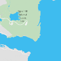

# hyda-base

`plot(openmap(x,path="hyda-base"))`

© [OpenStreetMap](http://openstreetmap.org/copyright) contributors. Data by [OpenStreetMap](http://openstreetmap.org), available under the [Open Database License](http://opendatacommons.org/licenses/odbl), cartography is licensed as [CC BY-SA](http://creativecommons.org/licenses/by-sa/2.0).

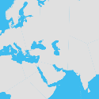

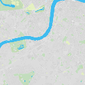

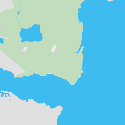

# hyda-roads

`plot(openmap(x,path="hyda-roads"))`

© [OpenStreetMap](http://openstreetmap.org/copyright) contributors. Data by [OpenStreetMap](http://openstreetmap.org), available under the [Open Database License](http://opendatacommons.org/licenses/odbl), cartography is licensed as [CC BY-SA](http://creativecommons.org/licenses/by-sa/2.0).

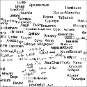

[figure not shown]

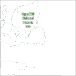

# humanitarian

`plot(openmap(x,path="humanitarian"))`

© [OpenStreetMap](http://openstreetmap.org/copyright) contributors. Data by [OpenStreetMap](http://openstreetmap.org), available under the [Open Database License](http://opendatacommons.org/licenses/odbl), cartography by [Humanitarian OSM team](http://hot.openstreetmap.org/about) is licensed as [CC BY-SA](http://creativecommons.org/licenses/by-sa/2.0).

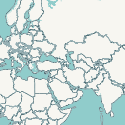

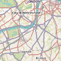

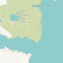

# cartodb

`plot(openmap(x,path="cartodb"))`

Map tiles by [CartoDB](http://carto.com) under [CC BY 3.0](http://creativecommons.org/licenses/by/3.0). Data by [OpenStreetMap](http://openstreetmap.org), available under the [Open Database License](http://opendatacommons.org/licenses/odbl)

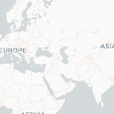

[figure not shown]

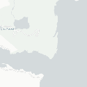

# cartodb-dark

`plot(openmap(x,path="cartodb-dark"))`

Map tiles by [CartoDB](http://carto.com) under [CC BY 3.0](http://creativecommons.org/licenses/by/3.0). Data by [OpenStreetMap](http://openstreetmap.org), available under the [Open Database License](http://opendatacommons.org/licenses/odbl)

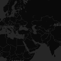

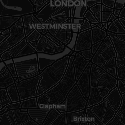

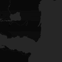

# sputnik

`plot(openmap(x,path="sputnik"))`

corp.sputnik.ru/maps.

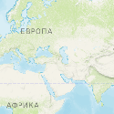

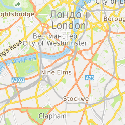

[figure not shown]

# stamen-toner

`plotRGB(openmap(x,path="stamen-toner"))`

Map tiles by [Stamen Design](http://stamen.com) under [CC BY 3.0](http://creativecommons.org/licenses/by/3.0). Data by [OpenStreetMap](http://openstreetmap.org), available under the [Open Database License](http://opendatacommons.org/licenses/odbl)

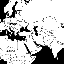

[figure not shown]

[figure not shown]

# stamen-watercolor

`plotRGB(openmap(x,path="stamen-watercolor"))`

Map tiles by [Stamen Design](http://stamen.com) under [CC BY 3.0](http://creativecommons.org/licenses/by/3.0). Data by [OpenStreetMap](http://openstreetmap.org), available under the [CC BY-SA](http://creativecommons.org/licenses/by/3.0)

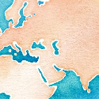

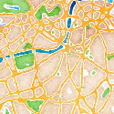

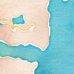

# stamen-terrain

`plot(openmap(x,path="stamen-terrain"))`

Map tiles by [Stamen Design](http://stamen.com) under [CC BY 3.0](http://creativecommons.org/licenses/by/3.0). Data by [OpenStreetMap](http://openstreetmap.org), available under the [CC BY-SA](http://creativecommons.org/licenses/by/3.0)

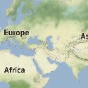

[figure not shown]

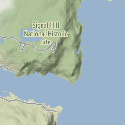

# stamen-terrain-labels

`plotRGB(openmap(x,path="stamen-terrain-labels"))`

Map tiles by [Stamen Design](http://stamen.com) under [CC BY 3.0](http://creativecommons.org/licenses/by/3.0). Data by [OpenStreetMap](http://openstreetmap.org), available under the [CC BY-SA](http://creativecommons.org/licenses/by/3.0)

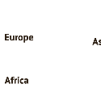

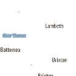

[figure not shown]

# stamen-terrain-background

`plot(openmap(x,path="stamen-terrain-background"))`

Map tiles by [Stamen Design](http://stamen.com) under [CC BY 3.0](http://creativecommons.org/licenses/by/3.0). Data by [OpenStreetMap](http://openstreetmap.org), available under the [CC BY-SA](http://creativecommons.org/licenses/by/3.0)

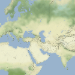

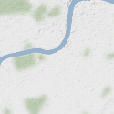

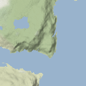

# Additional map layers

See [mc.bbbike.org/mc](http://mc.bbbike.org/mc/)

Michelin

```r
mPath = osmTiles(paste(
  'http://map3.viamichelin.com/map/mapdirect?map=',
  c('light','viamichelin'), '&', sep=''),
  xyz='zxy=', suffix =
    '&format=png&version=201503191157&layer=background')

africaMichelin = openmap(
  africaExtent, path=mPath,
  zoom=2,
  verbose=TRUE,
  crs = crsMerc)


for(D in names(africaMichelin)) {
  map.new(africaMichelin)
  plot(africaMichelin[[D]], add=TRUE)
  mtext(D, side=3, line=-2, outer=FALSE)
}
```

Stamen retina

```r
sPath = osmTiles('stamen-toner',
  suffix = '@2x.png')

africaS = openmap(
  africaTiles,
  buffer=-1,
  zoom=attributes(africaTiles)$tiles$zoom+1,
  path=sPath, verbose=TRUE)
africaS2 = tonerToTrans(africaS)

map.new(africaTiles)
plot(africaTiles[['opentopomap']], add=TRUE)
plot(africaS2, add=TRUE)

mtext(sPath, side=3, line=-2, outer=FALSE)
```

Komoot, Yandex, ESRI, F4map, and Sigma

```r
otherPaths = c(
  'https://a.tile.hosted.thunderforest.com/komoot-2/',
  'https://sat01.maps.yandex.net/tiles?l=sat&v=1.35.0&',
  'https://vec02.maps.yandex.net/tiles?l=map&v=4.40&',
  'https://server.arcgisonline.com/ArcGIS/rest/services/World_Physical_Map/MapServer/tile/',
  'https://server.arcgisonline.com/ArcGIS/rest/services/World_Imagery/MapServer/tile/',
  'https://services.arcgisonline.com/ArcGIS/rest/services/Ocean/World_Ocean_Base/MapServer/tile/',
  'https://tile2.f4map.com/tiles/f4_2d/',
  'http://tiles1.sigma-dc-control.com/layer8/')

africaExtra = openmap(
  africaExtent, path=otherPaths,
  zoom=2,
  verbose=TRUE,
  crs = crsMerc)

Spaths = unique(
  gsub("(red|green|blue|trans)$", "",
    names(africaExtra), ignore.case=TRUE)
)

for(D in Spaths) {

  oneTileName = grep(paste("^", D, "$", sep=""),
    names(africaExtra), value=TRUE)

  threeTilesName = grep(paste("^", D,
      "([rR]ed|[gG]reen|[bB]lue)$", sep=""),
    names(africaExtra),value=TRUE)

  map.new(africaExtra)
  if(length(threeTilesName)==3) {
    plotRGB(africaExtra[[threeTilesName]], add=TRUE)
  } else {
    plot(africaExtra[[oneTileName]], add=TRUE)
  }
  mtext(D, side=3, line=-2, outer=FALSE)
}
```